# IST 707 Final Project

### Jonathan Durbin

# Data Preparation

## Selecting Data | Searching

After spending too long rummaging through the Durbin family recipe book, I started to wonder how I could apply data analysis techniques to recipes.

The Durbin family recipe book sadly only contains less than 1,000 recipes, so external data sources must be found.

The following site provides a .zip file of some recipes scraped from common recipe sites. The recipes as listed in the database are provided under the ODC Attribution License.

- https://eightportions.com/datasets/Recipes
  - recipes-raw.zip
    - recipes_raw_nosource_fn.json: Foodnetwork.com
    - recipes_raw_nosource_epi.json: Epicurious.com
    - recipes_raw_nosource_ar.json: Allrecipes.com

## Selecting Data | Exploring

The data from Allrecipes.com is messy. I deleted all instances of `ADVERTISEMENT` and `,\n "ADVERTISEMENT"`. Example below.

[figure not shown]

Once that was completed, the three data files looked similar in format.

## Selecting Data | Cleaning

I removed the picture_link entries in all three files using the regular expression:

```
,\n\s*"picture_link": .*\n
```

[figure not shown]

## Selecting Data | Cleaning Pt. 2

I also had to remove some "empty" recipes. This regex helped:

```
\s{2}"[a-zA-Z0-9/.]*": \{\},\n
```

[figure not shown]

## Importing Packages

```python
from ingredient_parser.en import parse
import re
import ndjson
import pandas as pd
from mlxtend.frequent_patterns import apriori, association_rules
from mlxtend.preprocessing import TransactionEncoder
import nltk
from nltk.collocations import *
import networkx as nx
import matplotlib.pyplot as plt
import numpy as np
import math
```

## Parsing Ingredients

I want to remove as much redundant information as I can from each list of ingredients. This will help in the association rule mining analysis. There is a python package that does just this.

```python
print(
    f"""Original ingredient:
  '1 1/2 cups sugar'
After parsing:
  '{parse('1 1/2 cups sugar')['name']}'
"""
)
```

```
Original ingredient:
  '1 1/2 cups sugar'
After parsing:
  'sugar'
```

Works great in that case, but not great in others.

```python
print(
    f"""Original ingredient:
  '2 cups (about 9 1/2 ounces) whole almonds, toasted'
After parsing:
  '{parse('2 cups (about 9 1/2 ounces) whole almonds, toasted')['name']}'
"""
)
```

```
Original ingredient:
  '2 cups (about 9 1/2 ounces) whole almonds, toasted'
After parsing:
  '(about 9 1/2 ounces) whole almonds, toasted'
```

## Parsing Ingredients Part 2

I wrote a simple regex to remove unwanted elements that the python parser might miss.

```python
def rparse(i):
    pattern = r"""(?x)  # Use free-spacing mode.
        \s?\(.*\)\s?|   # something in parentheses with a space before/after
        ,.*$            # from a comma to the end of the string
        """
    return re.sub(pattern, "", i)
```

## Extract Relevant Information

With the python parser (and the function I wrote) I can now write code to extract the information I need.

- For association rule mining (AR), I need the names of all ingredients.
- For text mining (TM), I need the instructions for each recipe.

The below code extracts the ingredients (used in association rule mining) and instructions (used in text mining) from the three recipe files. The recipes are stored in ndjson (newline-delimited JSON) files.

```
files = ['ar', 'epi', 'fn']

for file_name in files:
    with open(f'data/recipes_raw_ndjson/recipes_raw_nosource_{file_name}.json') as f:
        data = ndjson.load(f)

    # AR: gather ingredient lists, parse, and write to a new file.
    data_ingredients = [recipe['ingredients'] for recipe in data]

    data_ingredients = [
      [rparse(parse(ingredient)['name']).lower() for ingredient in ingredients]
          for ingredients in data_ingredients
      ]

    with open(f'data/recipes_raw_ndjson/ingredients_{file_name}.txt', 'w') as f:
        for ingredients in data_ingredients:
            f.write(','.join(ingredients))
            f.write('\n')

    # TM: gather instructions and write to a new file
    data_instructions = [recipe['instructions'] for recipe in data]

    with open(f'data/recipes_raw_ndjson/instructions_{file_name}.txt', 'w') as f:
        for instruction in data_instructions:
            f.write(instruction)
            f.write('\n')
```

# Models

## Association Rule Modeling

To perform association rule mining, a list of sets of items must first be collected. In the case of this project, that consists of a list of ingredients for multiple recipes. This is similar to the common "shopping cart example" where each cart represents one list of items, then data from multiple shopping carts is collected. The data used in this project is stored as shown in the example below.

```
egg whites,egg yolks,sugar,brandy,rum
fresh chestnuts,veal stew meat,olive oil,chopped onion,chopped garlic,bay leaf
brown sugar,heavy cream,whole milk,pure vanilla extract,ground cinnamon
whole almonds,sugar,ground cinnamon,salt,large egg,large egg white,almond extract
butter,flour,milk,salt,freshly ground pepper
```

## Text Mining

This method of analysis involves breaking text into tokens, or individual words. In the case of this project, that involves obtaining a list of every individual word used in every recipe, unsorted and otherwise unmodified. From there, common and uninteresting words / characters are removed. These are referred to as stopwords. The text is also converted to lower-case for ease of analysis as individual sentences are not the priority - the collection of words (corpus) is.

The filtered and lowercase words are then stored as bigrams and rated according to raw frequency and a measure called Pointwise Mutual Information, or PMI. PMI is basically the likelihood of co-occurence of words.

The instructions are stored in a text file with each line containing the instructions from one recipe.

# Analysis

## Association Rule Modeling

First, read in the previously formatted and stored data.

```python
with open("data/recipes_raw_ndjson/ingredients_ar.txt", "r") as f:
    # strip off newline characters, convert to lowercase, and split by comma's
    data = [line.strip().lower().split(",") for line in f.readlines()]
```

Next, check the size of the data. It consists of a list of lists, where each inner list is one set of ingredients from a recipe.

```python
print(
    f"Unique items: {len(set([i for element in data for i in element]))}",
    f"\nTotal items: {len(data)}",
    f"\nFirst item: {data[0]}",
)
```

```
Unique items: 25322
Total items: 39522
First item: ['skinless', 'butter', 'cans condensed cream of chicken soup', 'onion', 'packages refrigerated biscuit dough']
```

Convert the transactional data to a one-hot-encoded matrix.

```python
te = TransactionEncoder()
te_fit = te.fit(data).transform(data)
df = pd.DataFrame(te_fit, columns=te.columns_)

df.head()
```

|  |  | % milk | 'bouqet garni' spice balls | 'sprinkle' suggestions: | * | + 1 tablespoon + 1 teaspoon all-purpose flour | - broken into pieces | - drained | - thawed | - to 10-inch whole-wheat tortillas | ... | zucchini chips: | zucchini chunks | zucchini cut in half lengthwise | zucchini matchsticks | zucchini noodles: | zucchini ribbons: | zucchini squashes | zucchinis | zucchinis - ends trimmed | zwieback cracker crumbs |
| --- | --- | --- | --- | --- | --- | --- | --- | --- | --- | --- | --- | --- | --- | --- | --- | --- | --- | --- | --- | --- | --- |
| 0 | False | False | False | False | False | False | False | False | False | False | ... | False | False | False | False | False | False | False | False | False | False |
| 1 | False | False | False | False | False | False | False | False | False | False | ... | False | False | False | False | False | False | False | False | False | False |
| 2 | False | False | False | False | False | False | False | False | False | False | ... | False | False | False | False | False | False | False | False | False | False |
| 3 | False | False | False | False | False | False | False | False | False | False | ... | False | False | False | False | False | False | False | False | False | False |
| 4 | False | False | False | False | False | False | False | False | False | False | ... | False | False | False | False | False | False | False | False | False | False |

5 rows × 25322 columns

As you can see, the parse functions were not perfectly accurate - it's prohibitively difficult to create ingredient parsing functions to a significant degree of accuracy. In fact, it it likely better to simply use more data.

Next, generate a ruleset using the apriori algorithm.

```python
ar_model = apriori(df, min_support=0.01, max_len=4, use_colnames=True)
```

Finally, calculate confidence, lift, leverage, and conviction using the `association_rules` function. Sort the data to find the (hopefully) most interesting rulesets.

```python
rules = association_rules(ar_model, metric="confidence", min_threshold=0.7)
rules = rules.sort_values(["confidence", "lift"], ascending=[False, False])
```

```python
rules.head()
```

|  | antecedents | consequents | antecedent support | consequent support | support | confidence | lift | leverage | conviction |
| --- | --- | --- | --- | --- | --- | --- | --- | --- | --- |
| 166 | (baking soda, egg, white sugar) | (all-purpose flour) | 0.011993 | 0.201736 | 0.010829 | 0.902954 | 4.475923 | 0.008410 | 8.225593 |
| 190 | (vegetable oil, baking soda, white sugar) | (all-purpose flour) | 0.011487 | 0.201736 | 0.010298 | 0.896476 | 4.443812 | 0.007981 | 7.710893 |
| 131 | (egg, white sugar, baking powder) | (all-purpose flour) | 0.012423 | 0.201736 | 0.011082 | 0.892057 | 4.421909 | 0.008576 | 7.395241 |
| 299 | (vegetable oil, baking soda, white sugar) | (salt) | 0.011487 | 0.299605 | 0.010146 | 0.883260 | 2.948079 | 0.006705 | 5.999608 |
| 160 | (baking soda, chopped walnuts, salt) | (all-purpose flour) | 0.011361 | 0.201736 | 0.010020 | 0.881960 | 4.371857 | 0.007728 | 6.762654 |

Interestingly, most ingredient combinations are reminiscent of pastries and homemade pies.

## Text Mining

First, import relevant packages and read in the data. There is a file that consists of all three sets of instructions grouped together, but it is simply too large for this project and this computer.

```python
filepath = "data/recipes_raw_ndjson/instructions_ar.txt"

with open(filepath, "r") as f:
    filetext = f.read()
```

Next, tokenize the file (or break sentences into individual words).

```python
filetokens = nltk.word_tokenize(filetext)
```

Convert each word to lowercase. This de-emphasizes the beginnings of sentences, but such information isn't relevant to this analysis.

```python
filetokens_lower = [w.lower() for w in filetokens]
```

Preview the first few tokens.

```python
print(len(filetokens_lower))
print(filetokens_lower[:30])
```

```
4637634
['place', 'the', 'chicken', ',', 'butter', ',', 'soup', ',', 'and', 'onion', 'in', 'a', 'slow', 'cooker', ',', 'and', 'fill', 'with', 'enough', 'water', 'to', 'cover', 'cover', ',', 'and', 'cook', 'for', '5', 'to', '6']
```

There are lots of tokens, but the next sections will remove a significant amount of redundant words and characters.

Next, open a file containing a pre-defined list of stopwords. Add in some extra stopwords that are specific to this corpus.

```python
fstop = open("data/smart.english.stop", "r")
stoptext = fstop.read()
fstop.close()

stopwords = nltk.word_tokenize(stoptext)
stopwords.extend(["small", "medium", "large", "medium-high", "high", "low"])
print(stopwords[:50])
```

```
["'s", 'a', "a's", 'able', 'about', 'above', 'according', 'accordingly', 'across', 'actually', 'after', 'afterwards', 'again', 'against', "ain't", 'all', 'allow', 'allows', 'almost', 'alone', 'along', 'already', 'also', 'although', 'always', 'am', 'among', 'amongst', 'an', 'and', 'another', 'any', '…
```

Define a filter to remove non-alphabet characters such as parentheses and numbers.

```python
def alpha_filter(w):
    pattern = re.compile("^[^a-z]+$")
    if pattern.match(w):
        return True
    else:
        return False
```

Finally, initialize an object to carry bigrams generated from the recipe instructions.

```python
bigram_measures = nltk.collocations.BigramAssocMeasures()

finder = BigramCollocationFinder.from_words(filetokens_lower)

finder.apply_word_filter(alpha_filter)
finder.apply_word_filter(lambda w: w in stopwords)
```

With the model trained, view the top 20 bigrams sorted by raw frequency and PMI.

```python
scored = finder.score_ngrams(bigram_measures.raw_freq)
for item, score in scored[:20]:
    print(f"{item}: {round(score, 4)}")
```

```
('preheat', 'oven'): 0.0027
('preheated', 'oven'): 0.0025
('olive', 'oil'): 0.0013
('baking', 'dish'): 0.0013
('reduce', 'heat'): 0.0013
('baking', 'sheet'): 0.0011
('brown', 'sugar'): 0.0009
('black', 'pepper'): 0.0009
('golden', 'brown'): 0.0009
('lemon', 'juice'): 0.0007
('baking', 'powder'): 0.0007
('cream', 'cheese'): 0.0007
('baking', 'soda'): 0.0006
('stirring', 'occasionally'): 0.0006
('flour', 'mixture'): 0.0005
('prepared', 'baking'): 0.0005
('sour', 'cream'): 0.0005
('salted', 'water'): 0.0005
('mixing', 'bowl'): 0.0005
('vanilla', 'extract'): 0.0005
```

Next, PMI:

```python
finder.apply_freq_filter(5)
scored = finder.score_ngrams(bigram_measures.pmi)
for item, score in scored[:20]:
    print(f"{item}: {round(score, 4)}")
```

```
('el', 'hanout'): 19.56
('ras', 'el'): 19.56
('panna', 'cotta'): 19.56
('dental', 'floss'): 19.3376
('fiddlehead', 'ferns'): 18.9523
('pina', 'colada'): 18.823
('beurre', 'blanc'): 18.6855
('ping', 'pong'): 18.6855
('granny', 'smith'): 18.56
('signature', 'russets'): 18.56
('bloody', 'mary'): 18.56
('hush', 'puppies'): 18.56
('local', 'extension'): 18.56
('multi-grain', 'medley'): 18.4929
('amish', 'friendship'): 18.4669
('sambal', 'oelek'): 18.3376
('grand', 'marnier'): 18.3376
('lily', 'buds'): 18.3376
('parmigiano', 'reggiano'): 18.145
('citric', 'acid'): 18.0575
```

I thought that "el" may have been an error in my parsing, but after some light googling, I found the following description on wikipedia:

> Ras el hanout or rass el hanout is a spice mix found in varying forms in Tunisia, Algeria, and Morocco. The name in Arabic means "head of the shop" and implies a mixture of the best spices the seller has to offer.

## Results: Association Rule Mining

Define a function to plot association rules:

```python
def draw_graph2(rules):
    G1 = nx.DiGraph()
    colors = np.random.rand(50)

    for (i, rule) in enumerate(rules.itertuples(index=False, name="Rule")):
        # c = f"C_{list(rule.consequents)[0]}"
        c = list(rule.consequents)[0]
        G1.add_node(c, node_type="consequent")
        for a in rule.antecedents:
            G1.add_edge(a, c, color=colors[i])

    edges = G1.edges()
    colors = [G1[u][v]["color"] for u, v in edges]
    node_colors = ["orange" if G1.nodes[n] else "yellow" for n in G1.nodes()]
    pos = nx.circular_layout(G1, scale=2)
    plt.figure(1, figsize=(100, 40), dpi=60)
    nx.draw(
        G1,
        pos,
        edgelist=edges,
        node_color=node_colors,
        edge_color=colors,
        width=10,
        with_labels=False,
        alpha=0.5,
        node_size=10000,
        arrowsize=100,
    )
    plt.margins(x=0.4)
    for p in pos:  # raise text positions
        pos[p][1] += 0.18
    nx.draw_networkx_labels(G1, pos, font_size=80, verticalalignment="top")
```

The below plot is of the top 20 association rules gathered from this set of data.

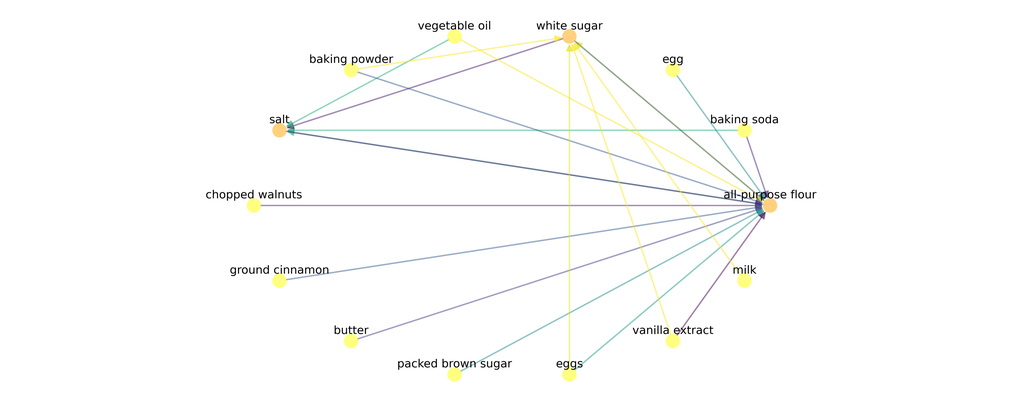

```python
draw_graph2(rules[:20])
```

Based on this figure, it is clear that all-purpose flour is a primary ingredient for many rule sets. Also, baking power, eggs, and vanilla extract seem to work with white sugar and all-purpose flour often. Similarly, vegetable oil and baking soda pair with salt and all-purpose flour.

## Results: Text Mining

The results of the text mining performed here reveal many common two-word phrases used in the cooking world. Expected phrases include granny smith, hush puppies, and citric acid. Unexpected phrases include ras el and el hanout, local extension, and amish friendship. By observing the pointwise mutual information of bigrams, new insights can be gleaned about lesser-known cooking techniques. Out of curiosity, the PMI of another set of recipe instructions will be checked.

```python
scored2 = finder2.score_ngrams(bigram_measures2.pmi)
for item, score in scored2[:20]:
    print(f"{item}: {round(score, 4)}")
```

```
('bedford', 'thompson'): 21.1077
('coyote', 'bait'): 21.1077
('hahn', 'estates'): 21.1077
('nitrous', 'oxide'): 21.1077
('sabor', 'italia'): 21.1077
('kung', 'pao'): 20.8446
('vice', 'versa'): 20.8446
('anna', 'williams'): 20.6222
('frankland', 'estate'): 20.6222
('gale', 'gand'): 20.6222
('grana', 'padano'): 20.6222
('paula', 'deen'): 20.5816
('nam', 'pla'): 20.4296
('kent', 'goldings'): 20.4296
('bungee', 'cords'): 20.2597
('piment', "d'espelette"): 20.2597
('pregnant', 'women'): 20.1077
('ina', 'garten'): 19.9702
('buon', 'appetito'): 19.9557
('bagna', 'cauda'): 19.8446
```

## Conclusions

To conclude, applying data analytics techniques to recipe data is not straight-forward, but practical for gaining insight into the world of cooking. It is clear that in order to gather deeper perspectives, much more time and research is required. The primary limiting factor in the research conducted during this project is the (largely) unstructured and "messy" recipe data. The best way to gain valuable insights is to collect more data. In fact, this project couldn't include all 200 Mb of data that was collected - the program which performed this analysis (RStudio) ran out of memory rather quickly. As a result, the code was switched to python in a jupyter notebook. Even then, using only a quarter of the data, one chunk of code could run for 2+ minutes.

Text mining showed that the two recipe corpuses examined - allrecipes and foodnetwork - contain different types of recipes. For instance, allrecipes seems to have more exotic recipes from non-american cultures. Meanwhile, foodnetwork has more wine and southern meat-based recipes. That being said, there is certainly more of a distinction to be made, but such research is outside the scope of this class.

## Extra

Favorite recipe:

```
{
  "instructions": "heat bacon, eat it",
  "ingredients": [],
  "title": "Fruit Butter"
}
```